# Project: Unsupervised Learning, Regression, and Classification Analysis on Real-World Datasets:

### Imported the necessary libraries namely:

```python
import pandas as pd
import numpy as np
import random
import matplotlib.pyplot as plt
%matplotlib inline
import seaborn as sns
import warnings
warnings.filterwarnings("ignore")
```

# Unsupervised Learning:

### Imported the dataset 'Online Retail.csv' into data frame 'df':

```python
df = pd.read_csv('OnlineRetail.csv',encoding= 'cp1252' , header=0)
```

## Exploratory Data Analysis

### Shape of the dataset (number of rows and columns):

```python
df.shape
```

```
(541909, 8)
```

### Column names in the data frame:

```python
df.columns
```

```
Index(['InvoiceNo', 'StockCode', 'Description', 'Quantity', 'InvoiceDate',
       'UnitPrice', 'CustomerID', 'Country'],
      dtype='object')
```

### General information about dataset:

This info contains start and end of the index and info about data types in dataset, and memory usage

```python
df.info()
```

```
<class 'pandas.core.frame.DataFrame'>
RangeIndex: 541909 entries, 0 to 541908
Data columns (total 8 columns):
 #   Column       Non-Null Count   Dtype
---  ------       --------------   -----
 0   InvoiceNo    541909 non-null  object
 1   StockCode    541909 non-null  object
 2   Description  540455 non-null  object
 3   Quantity     541909 non-null  int64
 4   InvoiceDate  541909 non-null  object
 5   UnitPrice    541909 non-null  float64
 6   CustomerID   406829 non-null  float64
 7   Country      541909 non-null  object
dtypes: float64(2), int64(1), object(5)
memory usage: 33.1+ MB
```

### Showing the first five rows of the data set:

```python
df.head()
```

|  | InvoiceNo | StockCode | Description | Quantity | InvoiceDate | UnitPrice | CustomerID | Country |
| --- | --- | --- | --- | --- | --- | --- | --- | --- |
| 0 | 536365 | 85123A | WHITE HANGING HEART T-LIGHT HOLDER | 6 | 12/1/2010 8:26 | 2.55 | 17850.0 | United Kingdom |
| 1 | 536365 | 71053 | WHITE METAL LANTERN | 6 | 12/1/2010 8:26 | 3.39 | 17850.0 | United Kingdom |
| 2 | 536365 | 84406B | CREAM CUPID HEARTS COAT HANGER | 8 | 12/1/2010 8:26 | 2.75 | 17850.0 | United Kingdom |
| 3 | 536365 | 84029G | KNITTED UNION FLAG HOT WATER BOTTLE | 6 | 12/1/2010 8:26 | 3.39 | 17850.0 | United Kingdom |
| 4 | 536365 | 84029E | RED WOOLLY HOTTIE WHITE HEART. | 6 | 12/1/2010 8:26 | 3.39 | 17850.0 | United Kingdom |

### Count the number of Null values in each column:

we can see that 'Description' and 'CustomerID' contain 1454 and 135080 null values respectively

```python
df.isnull().sum()
```

```
InvoiceNo           0
StockCode           0
Description      1454
Quantity            0
InvoiceDate         0
UnitPrice           0
CustomerID     135080
Country             0
dtype: int64
```

### Remove the null values:

As null values are not going to contribute hence we need to remove them.

```python
df.dropna(inplace=True)
```

### Congrates no null remaining:

we re-counted the null values in each column to confirm, we dont have any null value in the data set

```python
df.isnull().sum()
```

```
InvoiceNo      0
StockCode      0
Description    0
Quantity       0
InvoiceDate    0
UnitPrice      0
CustomerID     0
Country        0
dtype: int64
```

### Counted the number of duplicate records in dataset:

```python
print('Duplicates: {}'.format(df.duplicated().sum()))
```

```
Duplicates: 5225
```

### Remove Duplicate Records:

we need to remove these problematic duplicate record for clustering

```python
df.drop_duplicates(inplace=True)
```

### How many countries are there in Country column of the dataset?

```python
print('No. of cuntries in dataframe: {}'.format(pd.Series(df.Country.unique()).count()))
```

```
No. of cuntries in dataframe: 37
```

### Contry-wise order calculation:

we can observe that United Kingdom has most number of orders compared to the other countries

```python
temp = df[['CustomerID']].groupby(df.Country).count()

temp = temp.reset_index(drop = False)

temp.sort_values(by='CustomerID', ascending=False).rename(index=str, columns={"CustomerID": "Country wise number of order"})
```

|  | Country | Country wise number of order |
| --- | --- | --- |
| 35 | United Kingdom | 356728 |
| 14 | Germany | 9480 |
| 13 | France | 8475 |
| 10 | EIRE | 7475 |
| 30 | Spain | 2528 |
| 23 | Netherlands | 2371 |
| 3 | Belgium | 2069 |
| 32 | Switzerland | 1877 |
| 26 | Portugal | 1471 |
| 0 | Australia | 1258 |
| 24 | Norway | 1086 |
| 18 | Italy | 803 |
| 6 | Channel Islands | 757 |
| 12 | Finland | 695 |
| 7 | Cyprus | 611 |
| 31 | Sweden | 461 |
| 1 | Austria | 401 |
| 9 | Denmark | 389 |
| 19 | Japan | 358 |
| 25 | Poland | 341 |
| 33 | USA | 291 |
| 17 | Israel | 247 |
| 36 | Unspecified | 241 |
| 29 | Singapore | 229 |
| 16 | Iceland | 182 |
| 5 | Canada | 151 |
| 15 | Greece | 146 |
| 22 | Malta | 127 |
| 34 | United Arab Emirates | 68 |
| 11 | European Community | 61 |
| 27 | RSA | 58 |
| 20 | Lebanon | 45 |
| 21 | Lithuania | 35 |
| 4 | Brazil | 32 |
| 8 | Czech Republic | 30 |
| 2 | Bahrain | 17 |
| 28 | Saudi Arabia | 10 |

### CustomerID should be string, InvoiceDate should be date:

```python
df['CustomerID'] = df['CustomerID'].astype(str)
df['InvoiceDate'] = df['InvoiceDate'].astype('datetime64[ns]')
```

### Extract the time based features from InvoiceDate

```python
df["Year"] = (df["InvoiceDate"]).dt.year
df["Month"] = (df["InvoiceDate"]).dt.month
df["Day"] = (df["InvoiceDate"]).dt.day
df['weekday'] = df['InvoiceDate'].dt.weekday
```

### Create Revenue columns in the table:

```python
df['Revenue'] = df['Quantity']* df['UnitPrice']
```

### Keep the last two words as the type of products:

```python
a = df['Description'].str.split()
df['Type'] = a.apply(lambda x: ' '.join(x[-2:]))
```

### Quantity of Types:

```python
df['Type'].nunique()
```

```
2333
```

### What are the Top15 spend Most Clients?:

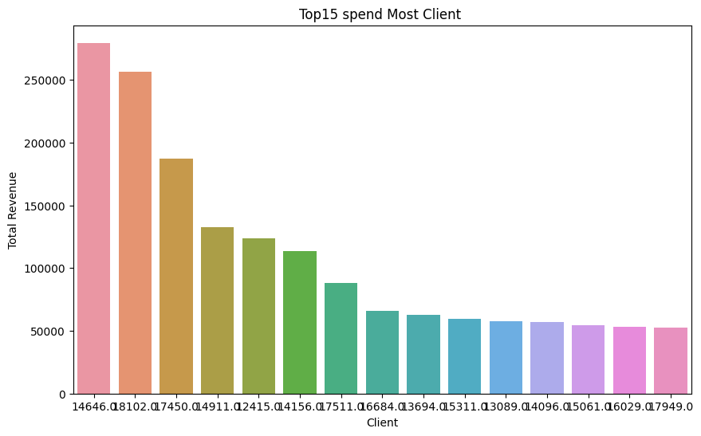

```python
Rev_Coustomer=df.groupby('CustomerID')['Revenue'].sum().sort_values(ascending=False).reset_index()[:15]
#Visualize
plt.figure(figsize=(10,6))
sns.barplot(x='CustomerID', y='Revenue', data=Rev_Coustomer)
plt.title("Top15 spend Most Client ")
plt.xlabel('Client')
plt.ylabel('Total Revenue')
plt.show()
```

### Whare are the Top20 Most Revenue Types?

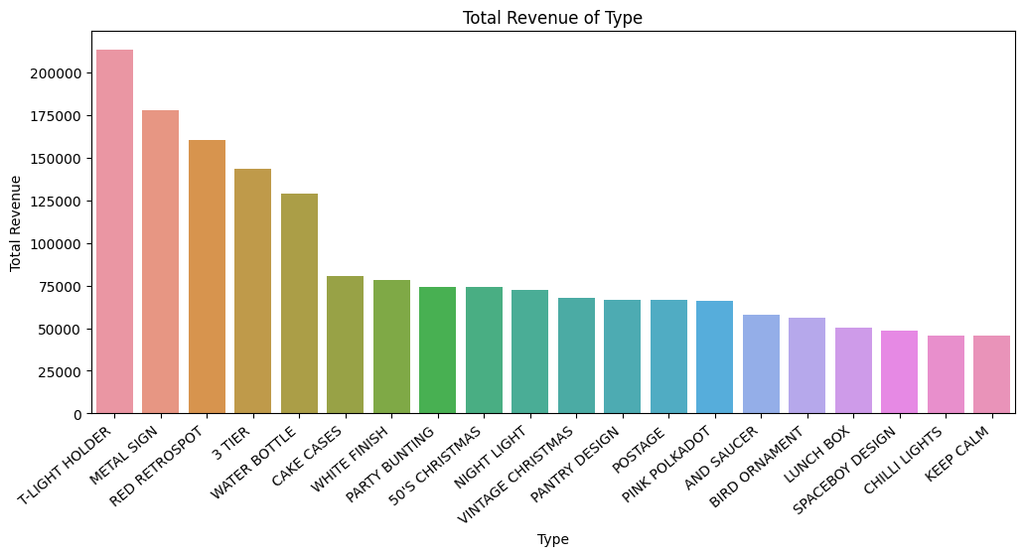

```python
# Get grouped of total Revenue and Type
Rev_Country=df.groupby('Type')['Revenue'].sum().sort_values(ascending=False).reset_index()[:20]
#Visualize
plt.figure(figsize=(12,5))
sns.barplot(x='Type', y='Revenue', data=Rev_Country)
plt.xticks(rotation=40,ha='right')
plt.title("Total Revenue of Type")
plt.xlabel('Type')
plt.ylabel('Total Revenue')
plt.show()
```

### Whare are the Top20 Most Revenue Orders?

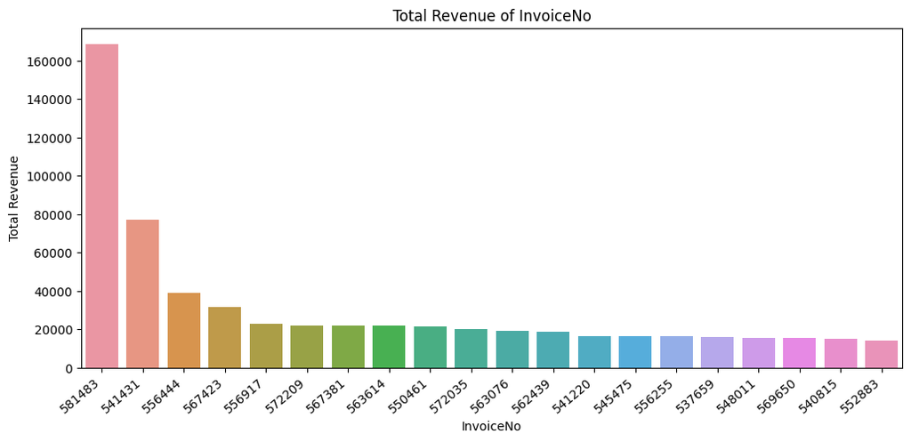

```python
# Get grouped of total Revenue and Type
Rev_Country=df.groupby('InvoiceNo')['Revenue'].sum().sort_values(ascending=False).reset_index()[:20]
#Visualize
plt.figure(figsize=(12,5))
sns.barplot(x='InvoiceNo', y='Revenue', data=Rev_Country)
plt.xticks(rotation=40,ha='right')
plt.title("Total Revenue of InvoiceNo")
plt.xlabel('InvoiceNo')
plt.ylabel('Total Revenue')
plt.show()
```

### Extract only numeric records from StockCode and InvoiceNo columns:

```python
df.StockCode = df.StockCode.str.extract('(\d+)', expand=False)
df.InvoiceNo = df.InvoiceNo.str.extract('(\d+)', expand=False)
df = df.dropna()
```

### Assign numeric codes to Type column:

```python
df['Type'] = df['Type'].astype('category').cat.codes
```

### Drop the unnecessary columns:

```python
df.drop(['Description','InvoiceDate','Country',], axis = 1, inplace = True)
```

### Reset the index of the data frame:

```python
df = df.reset_index(drop = True)
```

### N * N Matrix for clustering:

```python
df.head(15)
```

|  | InvoiceNo | StockCode | Quantity | UnitPrice | CustomerID | Year | Month | Day | weekday | Revenue | Type |
| --- | --- | --- | --- | --- | --- | --- | --- | --- | --- | --- | --- |
| 0 | 536365 | 85123 | 6 | 2.55 | 17850.0 | 2010 | 12 | 1 | 2 | 15.30 | 2033 |
| 1 | 536365 | 71053 | 6 | 3.39 | 17850.0 | 2010 | 12 | 1 | 2 | 20.34 | 1337 |
| 2 | 536365 | 84406 | 8 | 2.75 | 17850.0 | 2010 | 12 | 1 | 2 | 22.00 | 563 |
| 3 | 536365 | 84029 | 6 | 3.39 | 17850.0 | 2010 | 12 | 1 | 2 | 20.34 | 2236 |
| 4 | 536365 | 84029 | 6 | 3.39 | 17850.0 | 2010 | 12 | 1 | 2 | 20.34 | 2250 |
| 5 | 536365 | 22752 | 2 | 7.65 | 17850.0 | 2010 | 12 | 1 | 2 | 15.30 | 1419 |
| 6 | 536365 | 21730 | 6 | 4.25 | 17850.0 | 2010 | 12 | 1 | 2 | 25.50 | 2033 |
| 7 | 536366 | 22633 | 6 | 1.85 | 17850.0 | 2010 | 12 | 1 | 2 | 11.10 | 2161 |
| 8 | 536366 | 22632 | 6 | 1.85 | 17850.0 | 2010 | 12 | 1 | 2 | 11.10 | 1647 |
| 9 | 536367 | 84879 | 32 | 1.69 | 13047.0 | 2010 | 12 | 1 | 2 | 54.08 | 236 |
| 10 | 536367 | 22745 | 6 | 2.10 | 13047.0 | 2010 | 12 | 1 | 2 | 12.60 | 1639 |
| 11 | 536367 | 22748 | 6 | 2.10 | 13047.0 | 2010 | 12 | 1 | 2 | 12.60 | 1640 |
| 12 | 536367 | 22749 | 8 | 3.75 | 13047.0 | 2010 | 12 | 1 | 2 | 30.00 | 466 |
| 13 | 536367 | 22310 | 6 | 1.65 | 13047.0 | 2010 | 12 | 1 | 2 | 9.90 | 1381 |
| 14 | 536367 | 84969 | 6 | 4.25 | 13047.0 | 2010 | 12 | 1 | 2 | 25.50 | 575 |

### Standardize the values of all columns using StandardScaler:

```python
from sklearn.preprocessing import StandardScaler
scaler = StandardScaler()
df_sclaed = scaler.fit_transform(df)
```

## Clustering Techniques:

### The Elbow Method:

In the Elbow method, we initialise k-means and use the inertia attribute to identify the sum of squared distances of samples to the nearest cluster centre.</n> As k increases, the sum of squared distance tends to zero. Imagine we set k to its maximum value n (where n is number of samples) each sample will form its own cluster meaning sum of squared distances equals zero.</n> we plot of sum of squared distances for k in the range specified above. If the plot looks like an arm, then the elbow on the arm is optimal k.

### Finding the Sum of squared distances:

```python
from sklearn.cluster import KMeans
Sum_of_squared_distances = []
K = range(1,10)
for k in K:
    km = KMeans(n_clusters=k)
    km = km.fit(df_sclaed)
    Sum_of_squared_distances.append(km.inertia_)
```

### Ploting the Sum of squared distances::

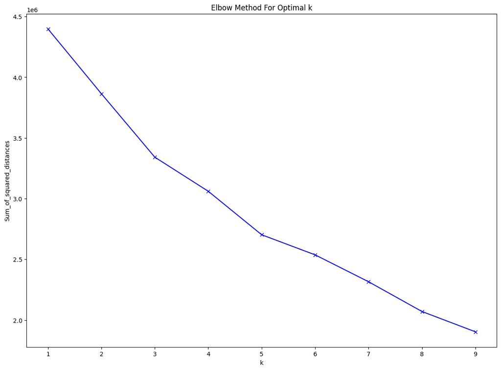

```python
plt.figure(figsize = (14,10))
plt.plot(K, Sum_of_squared_distances, 'bx-')
plt.xlabel('k')
plt.ylabel('Sum_of_squared_distances')
plt.title('Elbow Method For Optimal k')
plt.show()
```

##### As in the above plot we can see the plot have the first arm elbow at 3 hence the optimal number of clusters in our case is 3:

### Hence we Import KMeans from sklearn and fit it using k=3 clusters on our data set:

```python
from sklearn.cluster import KMeans

km = KMeans(
    n_clusters=3, init='random',
    n_init=10, max_iter=300,
    tol=1e-04, random_state=0
)
km = km.fit(df_sclaed)
```

### The centroid values generated by the algorithm:

```python
km.cluster_centers_
```

```
array([[ 7.83821013e-01, -9.42286783e-02, -8.48062172e-04,
        -4.28009451e-02,  2.10178983e-03,  2.65063758e-01,
         6.20334636e-01,  3.86373542e-02,  1.76381572e-02,
        -1.84372013e-03,  8.43030889e-03],
       [-8.35780226e-01,  1.14272398e-01,  1.90495750e-03,
         5.33158899e-02, -2.58744199e-02,  2.65063758e-01,
        -1.11661395e+00,  5.22552815e-02, -3.58249577e-02,
         2.57810695e-03, -1.72973918e-02],
       [-1.72188310e+00,  1.26629128e-01, -3.96602494e-03,
         4.93011337e-02,  1.33048822e-01, -3.77267721e+00,
         1.28859199e+00, -6.29254649e-01,  6.03816393e-02,
         4.84323039e-04,  2.98766645e-02]])
```

### The labels for each data point belongs to:

```python
print(km.labels_)
```

```
[2 2 2 ... 0 0 0]
```

### The unique values of clusters labels:

```python
pd.Series(km.labels_).unique()
```

```
array([2, 1, 0])
```

### Let's plot the data points again on the graph and visualize how the data has been clustered:

Here we are plotting the first column of the Data frame against the second column, This time we will plot the data along with their assigned label so that we can distinguish between the clusters.

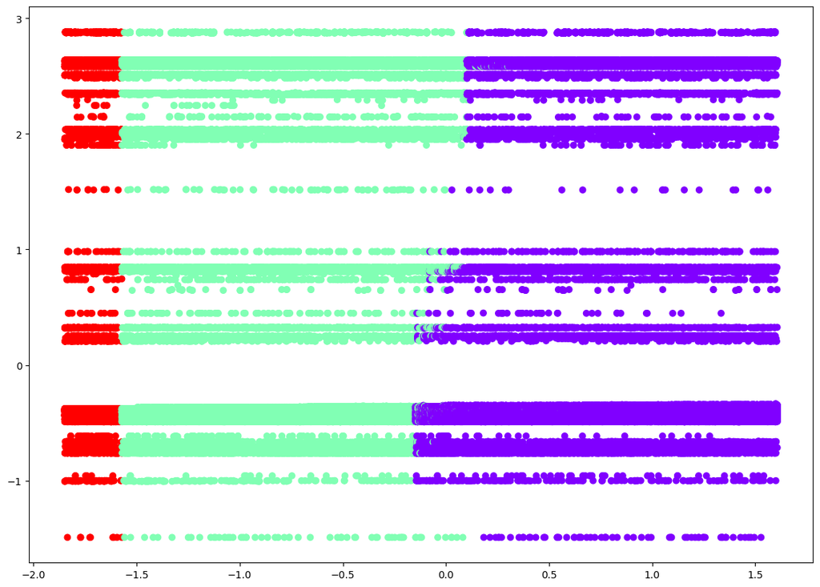

```python
plt.figure(figsize = (14,10))
plt.scatter(df_sclaed[:,0],df_sclaed[:,1], c=km.labels_, cmap='rainbow')
```

### Let's plot the points along with the centroid coordinates of each cluster to see how the centroid positions effects clustering:

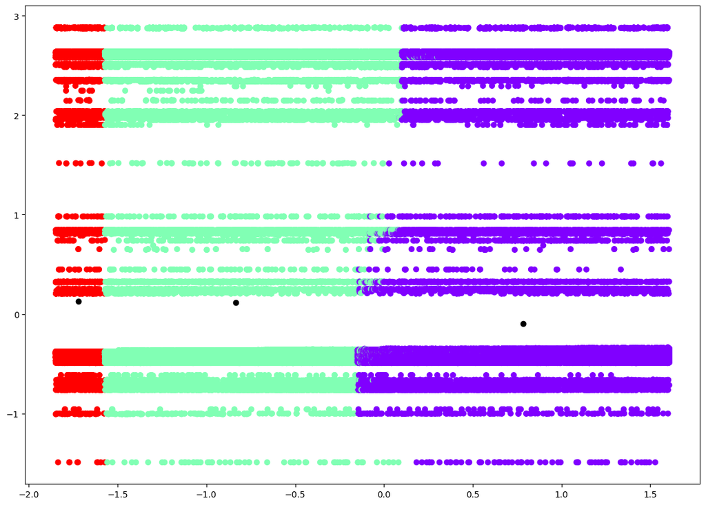

```python
plt.figure(figsize = (14,10))
plt.scatter(df_sclaed[:,0], df_sclaed[:,1], c=km.labels_, cmap='rainbow')
plt.scatter(km.cluster_centers_[:,0] ,km.cluster_centers_[:,1], color='black')
```

### Reduce the Dimentions of the data using Principal Component Analysis (PCA) and perform Kmeans again:

```python
from sklearn.decomposition import PCA
from mpl_toolkits.mplot3d import Axes3D

pca = PCA(n_components=2)

after_pca = pca.fit_transform(df_sclaed)
after_pca
```

```
array([[-1.99513780e-03, -1.64780343e+00],
       [-1.24362823e-02, -1.59486395e+00],
       [-2.21138152e-02, -1.68184206e+00],
       ...,
       [ 7.35087353e-02,  2.03092327e+00],
       [ 7.31999511e-02,  2.02634570e+00],
       [ 7.64703934e-02,  2.04754147e+00]])
```

### We fit KMeans again after PCA:

```python
from sklearn.cluster import KMeans

km = KMeans(
    n_clusters=3, init='random',
    n_init=10, max_iter=300,
    tol=1e-04, random_state=0
)
km = km.fit(after_pca)
```

### The centroid values generated by the algorithm after PCA:

```python
km.cluster_centers_
```

```
array([[-0.01829336, -0.1177043 ],
       [-0.0389983 , -1.5537958 ],
       [ 0.04369491,  1.33694943]])
```

### How the data has been clustered after PCA:

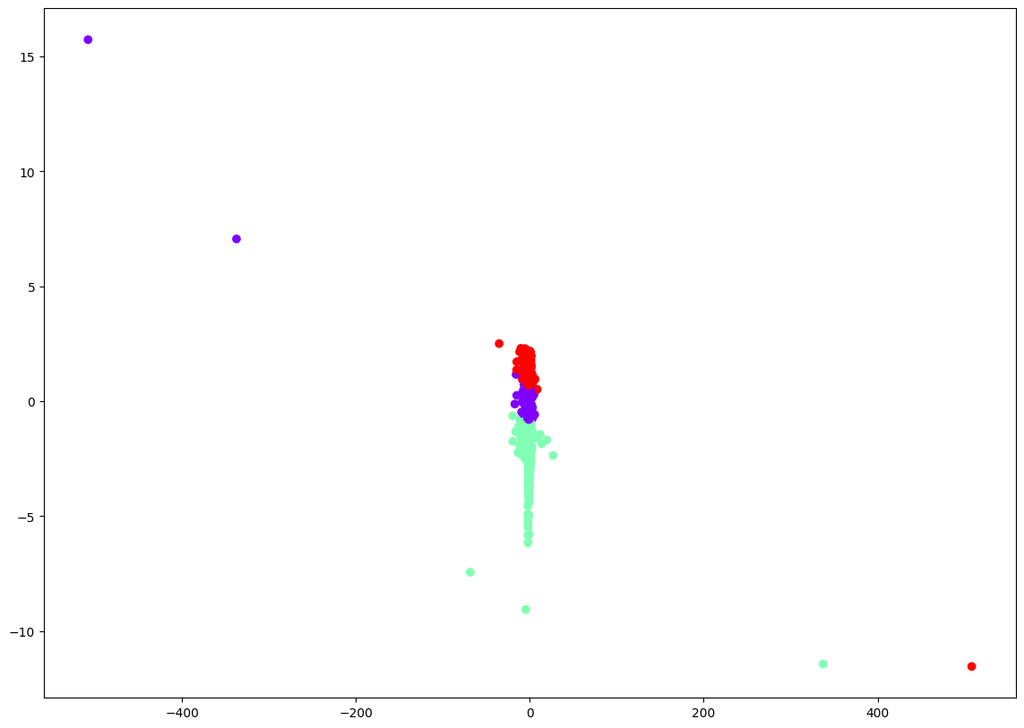

```python
plt.figure(figsize = (14,10))
plt.scatter(after_pca[:,0],after_pca[:,1], c=km.labels_, cmap='rainbow')
```

### plot the points along with the centroid coordinates of each cluster after PCA:

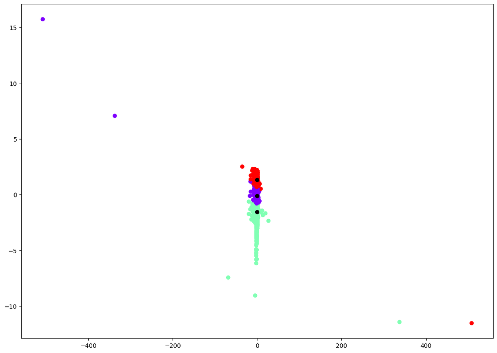

```python
plt.figure(figsize = (14,10))
plt.scatter(after_pca[:,0], after_pca[:,1], c=km.labels_, cmap='rainbow')
plt.scatter(km.cluster_centers_[:,0] ,km.cluster_centers_[:,1], color='black')
```

# Regression:

### Imported the necessary libraries :

```python
import pandas as pd
import numpy as np
import matplotlib.pyplot as plt
import seaborn as sns
import warnings
warnings.filterwarnings('ignore')
%matplotlib inline

from sklearn.linear_model import LinearRegression
from sklearn.tree import DecisionTreeRegressor
from sklearn.ensemble import RandomForestRegressor
from sklearn.neighbors import KNeighborsRegressor
from sklearn.ensemble import GradientBoostingRegressor

from sklearn.metrics import r2_score, mean_squared_error, mean_absolute_error
```

## Exploratory Data Analysis

### Imported the dataset 'Housing.csv' into data frame 'df':

```python
df = pd.read_csv('Housing.csv')
```

### Display the dimension of the dataset:

```python
df.shape
```

```
(545, 13)
```

### Display the column names of dataset:

```python
df.columns
```

```
Index(['price', 'area', 'bedrooms', 'bathrooms', 'stories', 'mainroad',
       'guestroom', 'basement', 'hotwaterheating', 'airconditioning',
       'parking', 'prefarea', 'furnishingstatus'],
      dtype='object')
```

### print the first ten rows of the data frame:

```python
df.head(10)
```

|  | price | area | bedrooms | bathrooms | stories | mainroad | guestroom | basement | hotwaterheating | airconditioning | parking | prefarea | furnishingstatus |
| --- | --- | --- | --- | --- | --- | --- | --- | --- | --- | --- | --- | --- | --- |
| 0 | 13300000 | 7420 | 4 | 2 | 3 | yes | no | no | no | yes | 2 | yes | furnished |
| 1 | 12250000 | 8960 | 4 | 4 | 4 | yes | no | no | no | yes | 3 | no | furnished |
| 2 | 12250000 | 9960 | 3 | 2 | 2 | yes | no | yes | no | no | 2 | yes | semi-furnished |
| 3 | 12215000 | 7500 | 4 | 2 | 2 | yes | no | yes | no | yes | 3 | yes | furnished |
| 4 | 11410000 | 7420 | 4 | 1 | 2 | yes | yes | yes | no | yes | 2 | no | furnished |
| 5 | 10850000 | 7500 | 3 | 3 | 1 | yes | no | yes | no | yes | 2 | yes | semi-furnished |
| 6 | 10150000 | 8580 | 4 | 3 | 4 | yes | no | no | no | yes | 2 | yes | semi-furnished |
| 7 | 10150000 | 16200 | 5 | 3 | 2 | yes | no | no | no | no | 0 | no | unfurnished |
| 8 | 9870000 | 8100 | 4 | 1 | 2 | yes | yes | yes | no | yes | 2 | yes | furnished |
| 9 | 9800000 | 5750 | 3 | 2 | 4 | yes | yes | no | no | yes | 1 | yes | unfurnished |

### Display the general information about the dataset:

```python
df.info()
```

```
<class 'pandas.core.frame.DataFrame'>
RangeIndex: 545 entries, 0 to 544
Data columns (total 13 columns):
 #   Column            Non-Null Count  Dtype
---  ------            --------------  -----
 0   price             545 non-null    int64
 1   area              545 non-null    int64
 2   bedrooms          545 non-null    int64
 3   bathrooms         545 non-null    int64
 4   stories           545 non-null    int64
 5   mainroad          545 non-null    object
 6   guestroom         545 non-null    object
 7   basement          545 non-null    object
 8   hotwaterheating   545 non-null    object
 9   airconditioning   545 non-null    object
 10  parking           545 non-null    int64
 11  prefarea          545 non-null    object
 12  furnishingstatus  545 non-null    object
dtypes: int64(6), object(7)
memory usage: 55.5+ KB
```

### Display the data types of each column in data frame:

```python
df.dtypes
```

```
price                int64
area                 int64
bedrooms             int64
bathrooms            int64
stories              int64
mainroad            object
guestroom           object
basement            object
hotwaterheating     object
airconditioning     object
parking              int64
prefarea            object
furnishingstatus    object
dtype: object
```

### Display the general Statistics about the dataset:

```python
df.describe()
```

|  | price | area | bedrooms | bathrooms | stories | parking |
| --- | --- | --- | --- | --- | --- | --- |
| count | 5.450000e+02 | 545.000000 | 545.000000 | 545.000000 | 545.000000 | 545.000000 |
| mean | 4.766729e+06 | 5150.541284 | 2.965138 | 1.286239 | 1.805505 | 0.693578 |
| std | 1.870440e+06 | 2170.141023 | 0.738064 | 0.502470 | 0.867492 | 0.861586 |
| min | 1.750000e+06 | 1650.000000 | 1.000000 | 1.000000 | 1.000000 | 0.000000 |
| 25% | 3.430000e+06 | 3600.000000 | 2.000000 | 1.000000 | 1.000000 | 0.000000 |
| 50% | 4.340000e+06 | 4600.000000 | 3.000000 | 1.000000 | 2.000000 | 0.000000 |
| 75% | 5.740000e+06 | 6360.000000 | 3.000000 | 2.000000 | 2.000000 | 1.000000 |
| max | 1.330000e+07 | 16200.000000 | 6.000000 | 4.000000 | 4.000000 | 3.000000 |

### Check are there any missing values in the columns of data frame:

```python
df.isnull().any()
```

```
price               False
area                False
bedrooms            False
bathrooms           False
stories             False
mainroad            False
guestroom           False
basement            False
hotwaterheating     False
airconditioning     False
parking             False
prefarea            False
furnishingstatus    False
dtype: bool
```

### Count the missing values in the columns of the data frame:

```python
df.isnull().sum()
```

```
price               0
area                0
bedrooms            0
bathrooms           0
stories             0
mainroad            0
guestroom           0
basement            0
hotwaterheating     0
airconditioning     0
parking             0
prefarea            0
furnishingstatus    0
dtype: int64
```

### Check are there any duplicated rows in the data frame:

```python
df.duplicated().sum()
```

```
0
```

### Boxplots to show the comparison of Price v/s bedroom:

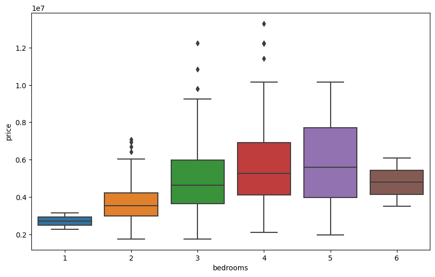

```python
plt.figure(figsize=(10, 6))
sns.boxplot(x=df['bedrooms'],y=df['price'])
plt.show()
```

### Violinplot to show the comparision Price v/s furnishing status:

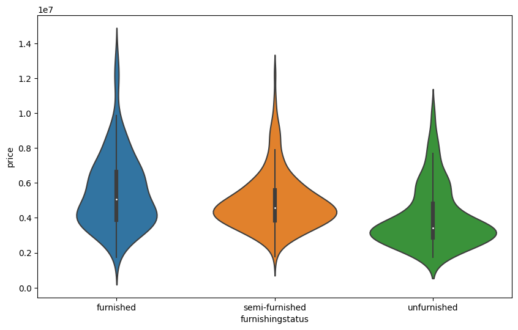

```python
plt.figure(figsize=(10, 6))
sns.violinplot(x=df['furnishingstatus'],y=df['price'])
plt.show()
```

Conclusion: Unfurnished houses are most economical

### Strip plot to show the comparision Price v/s Parking:

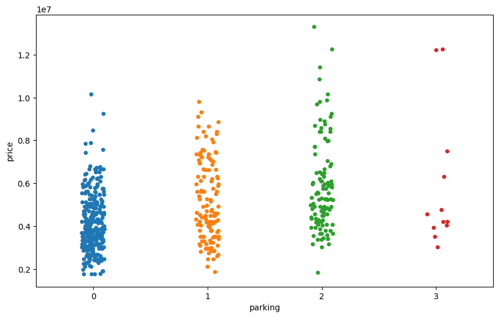

```python
plt.figure(figsize=(10, 6))
sns.stripplot(x=df['parking'],y=df['price'])
plt.show()
```

### Scatter and regression plot for price against furnishingstatus:

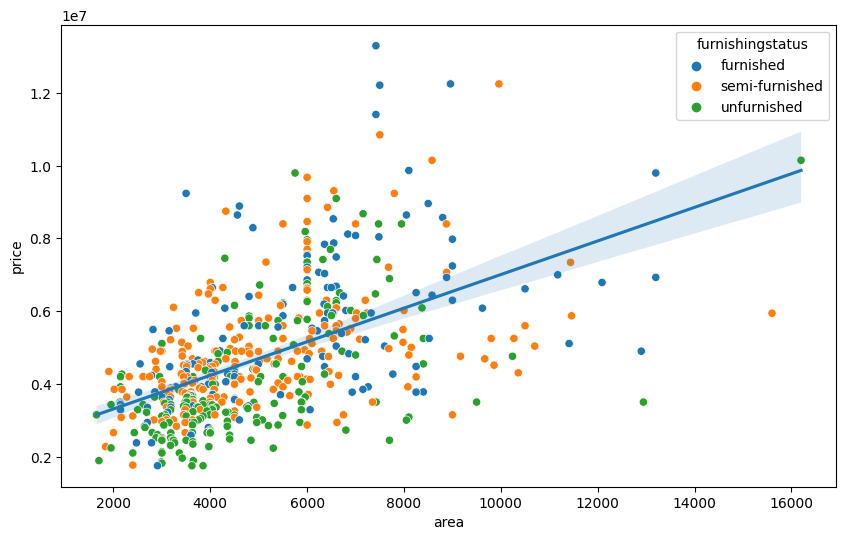

```python
plt.figure(figsize=(10, 6))
sns.scatterplot(x='area',y='price',data=df,hue='furnishingstatus')
sns.regplot(x='area',y='price',data=df,scatter=False)
plt.show()
```

### Handling outliers of price column:

```python
q1_pr=np.percentile(df['price'],25)
q2_pr=np.percentile(df['price'],75)
iqr_pr=q2_pr-q1_pr
lower_pr=q1_pr - 1.5*iqr_pr
upper_pr=q2_pr + 1.5*iqr_pr
df=df[(df['price']>=lower_pr) & (df['price']<=upper_pr)]
```

### Handling outliers of area Column:

```python
q1_ar=np.percentile(df['area'],25)
q2_ar=np.percentile(df['area'],75)
iqr_ar=q2_ar-q1_ar
lower_ar=q1_ar-1.5*iqr_ar
upper_ar=q2_ar+1.5*iqr_ar
df=df[(df['area']>=lower_ar) & (df['area']<=upper_ar)]
```

### How it looks like now:

```python
df = df.reset_index(drop = True)
df.head()
```

|  | price | area | bedrooms | bathrooms | stories | mainroad | guestroom | basement | hotwaterheating | airconditioning | parking | prefarea | furnishingstatus |
| --- | --- | --- | --- | --- | --- | --- | --- | --- | --- | --- | --- | --- | --- |
| 0 | 9100000 | 6000 | 4 | 1 | 2 | yes | no | yes | no | no | 2 | no | semi-furnished |
| 1 | 9100000 | 6600 | 4 | 2 | 2 | yes | yes | yes | no | yes | 1 | yes | unfurnished |
| 2 | 8960000 | 8500 | 3 | 2 | 4 | yes | no | no | no | yes | 2 | no | furnished |
| 3 | 8890000 | 4600 | 3 | 2 | 2 | yes | yes | no | no | yes | 2 | no | furnished |
| 4 | 8855000 | 6420 | 3 | 2 | 2 | yes | no | no | no | yes | 1 | yes | semi-furnished |

### Scatter plot for price vs furnishingstatus after removing outliers:

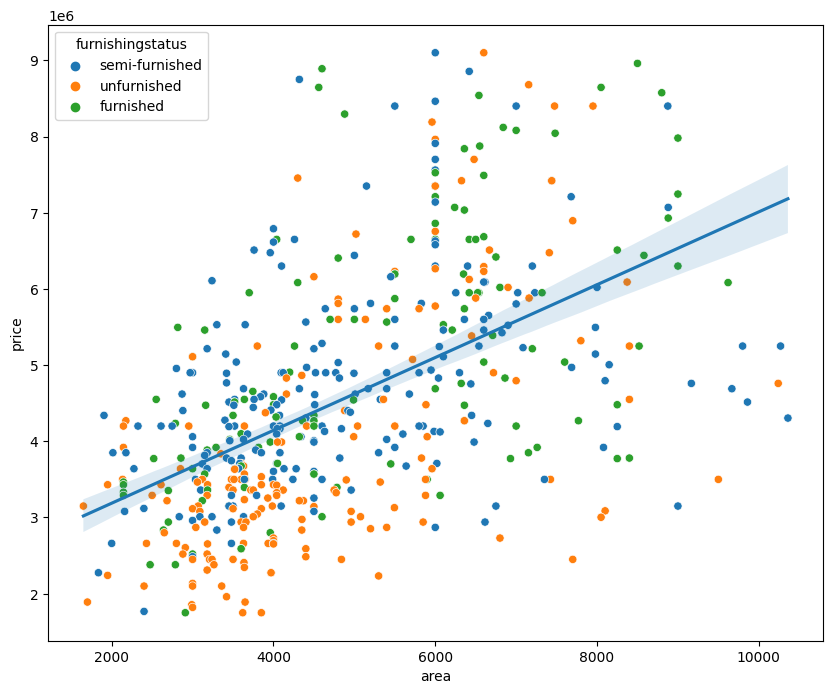

```python
plt.figure(figsize=(10,8))
sns.scatterplot(y='price',x='area',data=df,hue='furnishingstatus')
sns.regplot(y='price',x='area',data=df,scatter=False)
plt.show()
```

### Get the dummy variables of categorical features to convert them into numeric:

```python
df_dummy = pd.get_dummies(df, columns = ['mainroad','guestroom','basement','hotwaterheating','airconditioning','prefarea','furnishingstatus'])
df_dummy.head()
```

|  | price | area | bedrooms | bathrooms | stories | parking | mainroad_no | mainroad_yes | guestroom_no | guestroom_yes | ... | basement_yes | hotwaterheating_no | hotwaterheating_yes | airconditioning_no | airconditioning_yes | prefarea_no | prefarea_yes | furnishingstatus_furnished | furnishingstatus_semi-furnished | furnishingstatus_unfurnished |
| --- | --- | --- | --- | --- | --- | --- | --- | --- | --- | --- | --- | --- | --- | --- | --- | --- | --- | --- | --- | --- | --- |
| 0 | 9100000 | 6000 | 4 | 1 | 2 | 2 | 0 | 1 | 1 | 0 | ... | 1 | 1 | 0 | 1 | 0 | 1 | 0 | 0 | 1 | 0 |
| 1 | 9100000 | 6600 | 4 | 2 | 2 | 1 | 0 | 1 | 0 | 1 | ... | 1 | 1 | 0 | 0 | 1 | 0 | 1 | 0 | 0 | 1 |
| 2 | 8960000 | 8500 | 3 | 2 | 4 | 2 | 0 | 1 | 1 | 0 | ... | 0 | 1 | 0 | 0 | 1 | 1 | 0 | 1 | 0 | 0 |
| 3 | 8890000 | 4600 | 3 | 2 | 2 | 2 | 0 | 1 | 0 | 1 | ... | 0 | 1 | 0 | 0 | 1 | 1 | 0 | 1 | 0 | 0 |
| 4 | 8855000 | 6420 | 3 | 2 | 2 | 1 | 0 | 1 | 1 | 0 | ... | 0 | 1 | 0 | 0 | 1 | 0 | 1 | 0 | 1 | 0 |

5 rows × 21 columns

### Store Features into a feature matrix X and Response variable into a response vector y:

```python
#Features
#loc[what rows, what cols]
X = df_dummy.loc[:,df_dummy.columns != 'price']
#Response
y = df['price']
```

## Modelling: Regression Techniques:

### Divide the dataset into training set and testing set (80 percent train and 20 percent test):

```python
from sklearn.model_selection import train_test_split
X_train, X_test, y_train, y_test = train_test_split(X , y,  test_size=0.20, random_state=42)
```

# Linear Regression Model:

### Fit the Linear Regression model on training set and make prediction on testing set:

```python
#Initialize the model
Lr_regressor = LinearRegression()
# Fit the model on training set
Lr_regressor.fit(X_train, y_train)
#  make prediction on testing set
y_pred_lr = Lr_regressor.predict(X_test)
```

### Evaluate the Linear Regression model different evaluation scores:

```python
r2_score_Lr = r2_score(y_pred_lr,y_test)
print("The R2 score is: ",r2_score_Lr)
print("The mean absolute error is: ",mean_absolute_error(y_pred_lr,y_test))
print("The mean squared error is: ",mean_squared_error(y_pred_lr,y_test))
print("The root mean squared error is: ",np.sqrt(mean_squared_error(y_pred_lr,y_test)))
```

```
The R2 score is:  0.5315692802074748
The mean absolute error is:  734127.1131194807
The mean squared error is:  954173744480.8959
The root mean squared error is:  976818.1737052684
```

# DecisionTree Regression Model:

### Fit the Decision Tree model on training set and make prediction on testing set:

```python
#Initialize the model
Dt_regressor = DecisionTreeRegressor(max_depth = 14, random_state = 42)
# Fit the model on training set
Dt_regressor.fit(X_train, y_train)
#  make prediction on testing set
y_pred_dt = Dt_regressor.predict(X_test)
```

### Evaluate the Decision TRee model different evaluation scores:

```python
r2_score_Dt = r2_score(y_pred_dt, y_test)
print("The R2 score is: ",r2_score_Dt)
print("The mean absolute error is: ",mean_absolute_error(y_pred_dt,y_test))
print("The mean squared error is: ",mean_squared_error(y_pred_dt,y_test))
print("The root mean squared error is: ",np.sqrt(mean_squared_error(y_pred_dt,y_test)))
```

```
The R2 score is:  0.4539545407786232
The mean absolute error is:  994809.9358974359
The mean squared error is:  1739092123696.3674
The root mean squared error is:  1318746.4213018238
```

# Random Forest Regressor Model:

### Fit the Random Forest Regressor model on training set and make prediction on testing set:

```python
#Initialize the model
Rf_regressor = RandomForestRegressor(n_estimators=2000, max_depth = 17,random_state = 42)
# Fit the model on training set
Rf_regressor.fit(X_train, y_train)
#  make prediction on testing set
y_pred_rf = Rf_regressor.predict(X_test)
```

### Evaluate the Random Forest Regressor different evaluation scores:

```python
r2_score_Rf = r2_score(y_pred_rf, y_test)
print("The R2 score is: ",r2_score_Rf)
print("The mean absolute error is: ",mean_absolute_error(y_pred_rf,y_test))
print("The mean squared error is: ",mean_squared_error(y_pred_rf,y_test))
print("The root mean squared error is: ",np.sqrt(mean_squared_error(y_pred_rf,y_test)))
```

```
The R2 score is:  0.4814053021700493
The mean absolute error is:  765975.9838985465
The mean squared error is:  1071503708221.946
The root mean squared error is:  1035134.6328965841
```

# Gradient Boosting Regressor Model:

### Fit the Gradient Boosting Regressor model on training set and make prediction on testing set:

```python
#Initialize the model
Gbr_regressor = GradientBoostingRegressor( n_estimators=5000 , max_depth = 4,random_state = 42)
# Fit the model on training set
Gbr_regressor.fit(X_train, y_train)
#  make prediction on testing set
y_pred_gbr = Gbr_regressor.predict(X_test)
```

### Evaluate the Gradient Boosting Regressor using different evaluation scores:

```python
r2_score_gbr = r2_score(y_pred_gbr, y_test)
print("The R2 score is: ",r2_score_gbr)
print("The mean absolute error is: ",mean_absolute_error(y_pred_gbr,y_test))
print("The mean squared error is: ",mean_squared_error(y_pred_gbr,y_test))
print("The root mean squared error is: ",np.sqrt(mean_squared_error(y_pred_gbr,y_test)))
```

```
The R2 score is:  0.5477224636961792
The mean absolute error is:  813579.8306578965
The mean squared error is:  1182570057677.5244
The root mean squared error is:  1087460.370623925
```

### Model Comparison:

### Comparing Regression models(in terms of R2 score) in the form of a table:

```python
# List of model names
models = ['Linear Regression', 'Decision Tree Regressor', 'Random Forest Regressor', 'Gradient Boosting Regressor']

# Corresponding accuracy scores
scores = [r2_score_Lr, r2_score_Dt, r2_score_Rf, r2_score_gbr]

# Comparing models' performance
performance = pd.DataFrame(list(zip(models, scores)), columns=['Models', 'R2_score'])

# Displaying the performance table
performance
```

|  | Models | R2_score |
| --- | --- | --- |
| 0 | Linear Regression | 0.531569 |
| 1 | Decision Tree Regressor | 0.453955 |
| 2 | Random Forest Regressor | 0.481405 |
| 3 | Gradient Boosting Regressor | 0.547722 |

### Comparing Regression models in the form of a bar graph

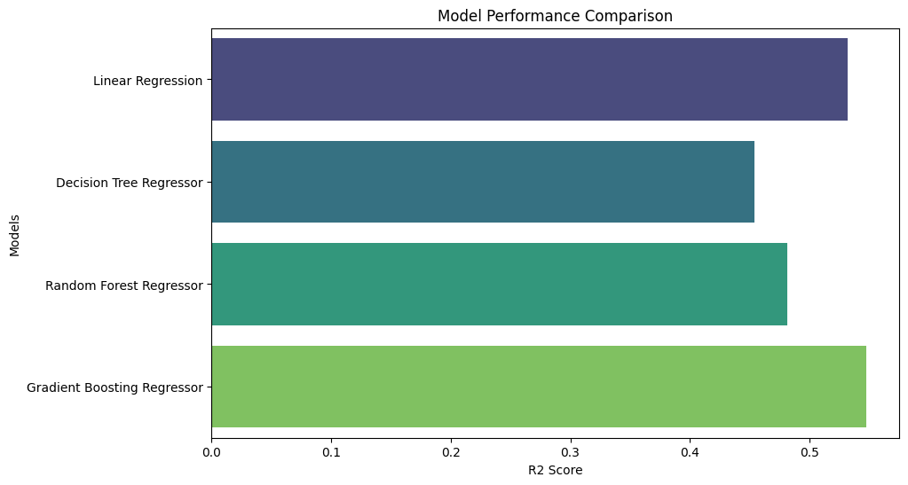

```python
plt.figure(figsize=(10, 6))
sns.barplot(x='R2_score', y='Models', data=performance, palette='viridis')
plt.xlabel('R2 Score')
plt.ylabel('Models')
plt.title('Model Performance Comparison')
plt.show()
```

# Classification:

### Imported All the necessary libraries:

```python
import pandas as pd
import numpy as np
import matplotlib.pyplot as plt
%matplotlib inline
import seaborn as sns
import matplotlib.ticker as mtick
from sklearn.preprocessing import StandardScaler, MinMaxScaler

from sklearn.linear_model import LogisticRegression
from sklearn.tree import DecisionTreeClassifier
from sklearn.ensemble import RandomForestClassifier
from sklearn.svm import SVC
from sklearn.ensemble import AdaBoostClassifier
from sklearn.neighbors import KNeighborsClassifier
#!pip install xgboost
from xgboost import XGBClassifier
from sklearn.model_selection import GridSearchCV
from sklearn.metrics import accuracy_score
from sklearn.metrics import roc_auc_score
```

### Read the Data set and store it in a pandas Data Frame :

```python
df = pd.read_csv('heart_failure_clinical_records_dataset.csv')
```

# Exploratory Data Analysis:

### Display the dimension of the dataset:

```python
df.shape
```

```
(299, 13)
```

### Display the column names of dataset:

```python
df.columns
```

```
Index(['age', 'anaemia', 'creatinine_phosphokinase', 'diabetes',
       'ejection_fraction', 'high_blood_pressure', 'platelets',
       'serum_creatinine', 'serum_sodium', 'sex', 'smoking', 'time',
       'DEATH_EVENT'],
      dtype='object')
```

### print the first ten rows of the data frame:

```python
df.head(10)
```

|  | age | anaemia | creatinine_phosphokinase | diabetes | ejection_fraction | high_blood_pressure | platelets | serum_creatinine | serum_sodium | sex | smoking | time | DEATH_EVENT |
| --- | --- | --- | --- | --- | --- | --- | --- | --- | --- | --- | --- | --- | --- |
| 0 | 75.0 | 0 | 582 | 0 | 20 | 1 | 265000.00 | 1.9 | 130 | 1 | 0 | 4 | 1 |
| 1 | 55.0 | 0 | 7861 | 0 | 38 | 0 | 263358.03 | 1.1 | 136 | 1 | 0 | 6 | 1 |
| 2 | 65.0 | 0 | 146 | 0 | 20 | 0 | 162000.00 | 1.3 | 129 | 1 | 1 | 7 | 1 |
| 3 | 50.0 | 1 | 111 | 0 | 20 | 0 | 210000.00 | 1.9 | 137 | 1 | 0 | 7 | 1 |
| 4 | 65.0 | 1 | 160 | 1 | 20 | 0 | 327000.00 | 2.7 | 116 | 0 | 0 | 8 | 1 |
| 5 | 90.0 | 1 | 47 | 0 | 40 | 1 | 204000.00 | 2.1 | 132 | 1 | 1 | 8 | 1 |
| 6 | 75.0 | 1 | 246 | 0 | 15 | 0 | 127000.00 | 1.2 | 137 | 1 | 0 | 10 | 1 |
| 7 | 60.0 | 1 | 315 | 1 | 60 | 0 | 454000.00 | 1.1 | 131 | 1 | 1 | 10 | 1 |
| 8 | 65.0 | 0 | 157 | 0 | 65 | 0 | 263358.03 | 1.5 | 138 | 0 | 0 | 10 | 1 |
| 9 | 80.0 | 1 | 123 | 0 | 35 | 1 | 388000.00 | 9.4 | 133 | 1 | 1 | 10 | 1 |

### Print the Data types of the columns :

```python
df.dtypes
```

```
age                         float64
anaemia                       int64
creatinine_phosphokinase      int64
diabetes                      int64
ejection_fraction             int64
high_blood_pressure           int64
platelets                   float64
serum_creatinine            float64
serum_sodium                  int64
sex                           int64
smoking                       int64
time                          int64
DEATH_EVENT                   int64
dtype: object
```

### Display the general Statistics about the dataset:

```python
df.info()
```

```
<class 'pandas.core.frame.DataFrame'>
RangeIndex: 299 entries, 0 to 298
Data columns (total 13 columns):
 #   Column                    Non-Null Count  Dtype
---  ------                    --------------  -----
 0   age                       299 non-null    float64
 1   anaemia                   299 non-null    int64
 2   creatinine_phosphokinase  299 non-null    int64
 3   diabetes                  299 non-null    int64
 4   ejection_fraction         299 non-null    int64
 5   high_blood_pressure       299 non-null    int64
 6   platelets                 299 non-null    float64
 7   serum_creatinine          299 non-null    float64
 8   serum_sodium              299 non-null    int64
 9   sex                       299 non-null    int64
 10  smoking                   299 non-null    int64
 11  time                      299 non-null    int64
 12  DEATH_EVENT               299 non-null    int64
dtypes: float64(3), int64(10)
memory usage: 30.5 KB
```

### Display the general Statistics about the dataset:

```python
df.describe(include = 'all')
```

|  | age | anaemia | creatinine_phosphokinase | diabetes | ejection_fraction | high_blood_pressure | platelets | serum_creatinine | serum_sodium | sex | smoking | time | DEATH_EVENT |
| --- | --- | --- | --- | --- | --- | --- | --- | --- | --- | --- | --- | --- | --- |
| count | 299.000000 | 299.000000 | 299.000000 | 299.000000 | 299.000000 | 299.000000 | 299.000000 | 299.00000 | 299.000000 | 299.000000 | 299.00000 | 299.000000 | 299.00000 |
| mean | 60.833893 | 0.431438 | 581.839465 | 0.418060 | 38.083612 | 0.351171 | 263358.029264 | 1.39388 | 136.625418 | 0.648829 | 0.32107 | 130.260870 | 0.32107 |
| std | 11.894809 | 0.496107 | 970.287881 | 0.494067 | 11.834841 | 0.478136 | 97804.236869 | 1.03451 | 4.412477 | 0.478136 | 0.46767 | 77.614208 | 0.46767 |
| min | 40.000000 | 0.000000 | 23.000000 | 0.000000 | 14.000000 | 0.000000 | 25100.000000 | 0.50000 | 113.000000 | 0.000000 | 0.00000 | 4.000000 | 0.00000 |
| 25% | 51.000000 | 0.000000 | 116.500000 | 0.000000 | 30.000000 | 0.000000 | 212500.000000 | 0.90000 | 134.000000 | 0.000000 | 0.00000 | 73.000000 | 0.00000 |
| 50% | 60.000000 | 0.000000 | 250.000000 | 0.000000 | 38.000000 | 0.000000 | 262000.000000 | 1.10000 | 137.000000 | 1.000000 | 0.00000 | 115.000000 | 0.00000 |
| 75% | 70.000000 | 1.000000 | 582.000000 | 1.000000 | 45.000000 | 1.000000 | 303500.000000 | 1.40000 | 140.000000 | 1.000000 | 1.00000 | 203.000000 | 1.00000 |
| max | 95.000000 | 1.000000 | 7861.000000 | 1.000000 | 80.000000 | 1.000000 | 850000.000000 | 9.40000 | 148.000000 | 1.000000 | 1.00000 | 285.000000 | 1.00000 |

### Check are there any missing values in the columns of data frame:

```python
df.isnull().any()
```

```
age                         False
anaemia                     False
creatinine_phosphokinase    False
diabetes                    False
ejection_fraction           False
high_blood_pressure         False
platelets                   False
serum_creatinine            False
serum_sodium                False
sex                         False
smoking                     False
time                        False
DEATH_EVENT                 False
dtype: bool
```

### Count the missing values in the columns of the data frame:

```python
df.isnull().sum()
```

```
age                         0
anaemia                     0
creatinine_phosphokinase    0
diabetes                    0
ejection_fraction           0
high_blood_pressure         0
platelets                   0
serum_creatinine            0
serum_sodium                0
sex                         0
smoking                     0
time                        0
DEATH_EVENT                 0
dtype: int64
```

### A Bar graph showing values of DEATH_EVENT column:

```python
ValueCounts_DEATH_EVENT = df['DEATH_EVENT'].value_counts()
ValueCounts_DEATH_EVENT
```

```
0    203
1     96
Name: DEATH_EVENT, dtype: int64
```

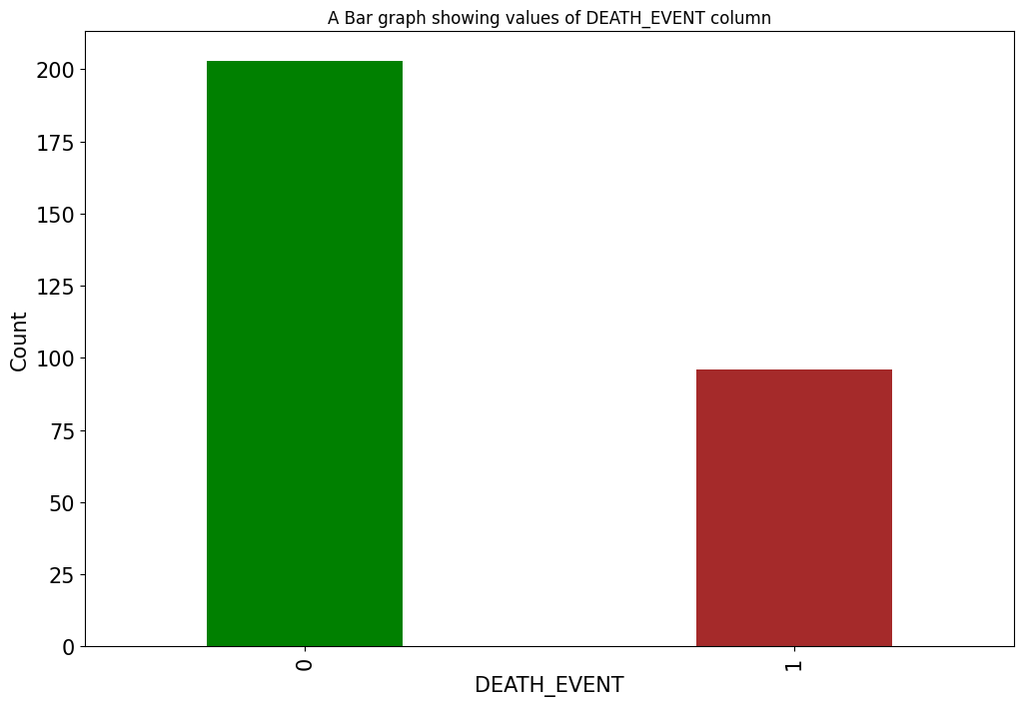

```python
ax = ValueCounts_DEATH_EVENT.plot(kind='bar',figsize=(12,8), width=0.40 ,color=['green','brown'] ,fontsize=15, title='A Bar graph showing values of DEATH_EVENT column' )
ax.set_xlabel("DEATH_EVENT",fontsize=15)
ax.set_ylabel("Count",fontsize=15)
plt.show()
```

As we can observe here that we have class imbalance in the values of DEATH_EVENT

### Histogram to show the distribution of the values of age:

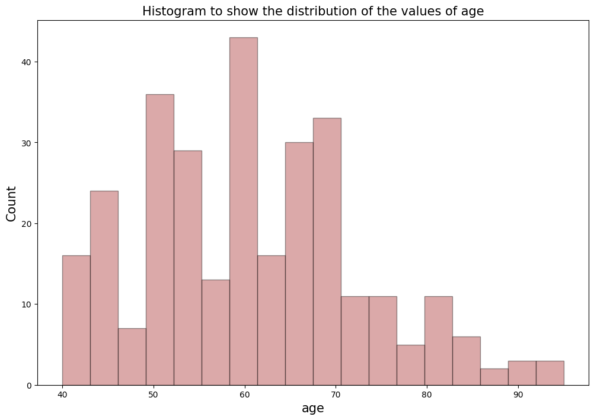

```python
plt.figure(figsize = (12,8))
ax = sns.distplot(df['age'], hist=True, kde=False,
             bins=int(180/10), color = 'brown',
             hist_kws={'edgecolor':'black'},
             kde_kws={'linewidth': 4})

ax.set_ylabel('Count', fontsize = 15)
ax.set_xlabel('age', fontsize = 15)
ax.set_title('Histogram to show the distribution of the values of age', fontsize = 15)
plt.show()
```

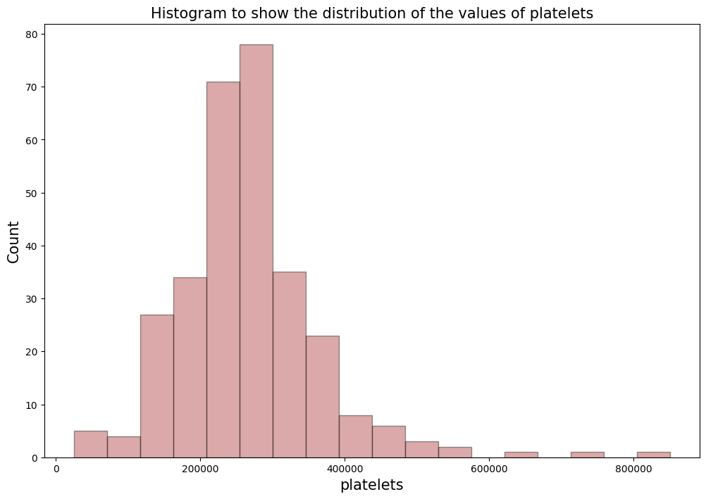

```python
plt.figure(figsize = (12,8))
ax = sns.distplot(df['platelets'], hist=True, kde=False,
             bins=int(180/10), color = 'brown',
             hist_kws={'edgecolor':'black'},
             kde_kws={'linewidth': 4})

ax.set_ylabel('Count', fontsize = 15)
ax.set_xlabel('platelets', fontsize = 15)
ax.set_title('Histogram to show the distribution of the values of platelets', fontsize = 15)
plt.show()
```

### A stacked bar graph to show the DEATH_EVENT by Diabetes value:

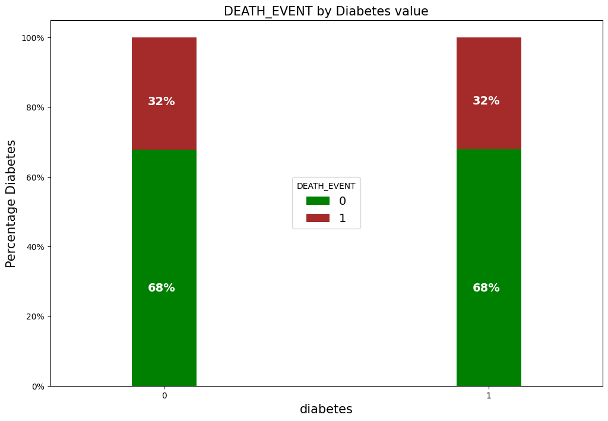

```python
colors = ['green','brown']
Diabetes_label = df.groupby(['diabetes','DEATH_EVENT']).size().unstack()
ax = (Diabetes_label.T*100.0 / Diabetes_label.T.sum()).T.plot(kind='bar',
                                                                width = 0.2,
                                                                stacked = True,
                                                                rot = 0,
                                                                figsize = (12,8),
                                                                color = colors)
ax.yaxis.set_major_formatter(mtick.PercentFormatter())
ax.legend(loc='center',prop={'size':14},title = 'DEATH_EVENT')
ax.set_ylabel('Percentage Diabetes', fontsize = 15)
ax.set_xlabel('diabetes',  fontsize = 15)
ax.set_title('DEATH_EVENT by Diabetes value', fontsize = 15)

for p in ax.patches:
    width, height = p.get_width(), p.get_height()
    x, y = p.get_xy()
    ax.annotate('{:.0f}%'.format(height), (p.get_x()+.25*width, p.get_y()+.4*height),
                color = 'white',
               weight = 'bold',size =14)
```

### A stacked bar graph to show the DEATH_EVENT by anaemia value:

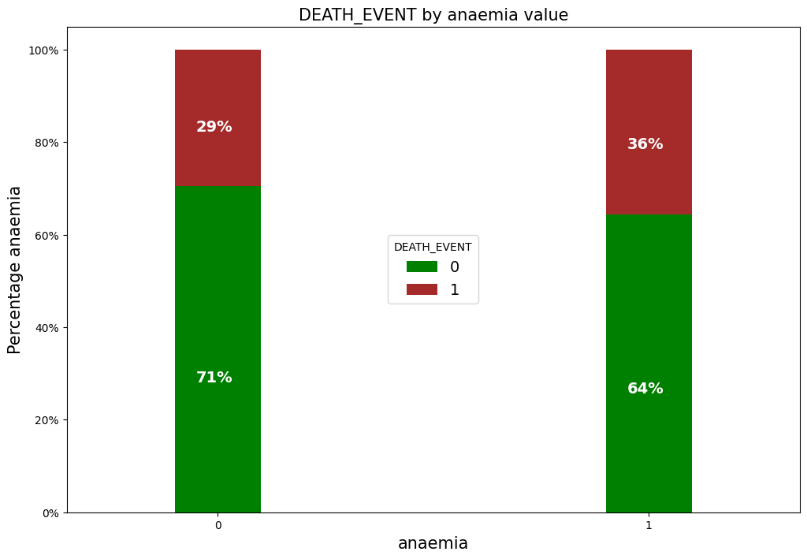

```python
colors = ['green','brown']
anaemia_label = df.groupby(['anaemia','DEATH_EVENT']).size().unstack()
ax = (anaemia_label.T*100.0 / anaemia_label.T.sum()).T.plot(kind='bar',
                                                                width = 0.2,
                                                                stacked = True,
                                                                rot = 0,
                                                                figsize = (12,8),
                                                                color = colors)
ax.yaxis.set_major_formatter(mtick.PercentFormatter())
ax.legend(loc='center',prop={'size':14},title = 'DEATH_EVENT')
ax.set_ylabel('Percentage anaemia', fontsize = 15)
ax.set_xlabel('anaemia',  fontsize = 15)
ax.set_title('DEATH_EVENT by anaemia value', fontsize = 15)

for p in ax.patches:
    width, height = p.get_width(), p.get_height()
    x, y = p.get_xy()
    ax.annotate('{:.0f}%'.format(height), (p.get_x()+.25*width, p.get_y()+.4*height),
                color = 'white',
               weight = 'bold',size =14)
```

### A stacked bar graph to show the DEATH_EVENT by smoking value:

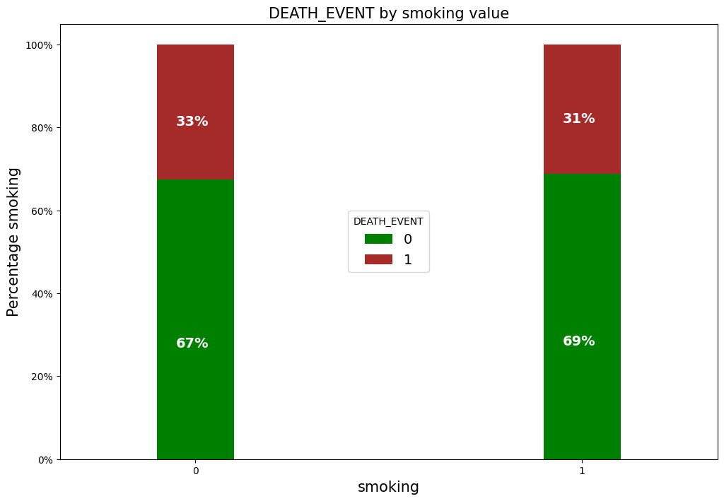

```python
colors = ['green','brown']
smoking_label = df.groupby(['smoking','DEATH_EVENT']).size().unstack()
ax = (smoking_label.T*100.0 / smoking_label.T.sum()).T.plot(kind='bar',
                                                                width = 0.2,
                                                                stacked = True,
                                                                rot = 0,
                                                                figsize = (12,8),
                                                                color = colors)
ax.yaxis.set_major_formatter(mtick.PercentFormatter())
ax.legend(loc='center',prop={'size':14},title = 'DEATH_EVENT')
ax.set_ylabel('Percentage smoking', fontsize = 15)
ax.set_xlabel('smoking',  fontsize = 15)
ax.set_title('DEATH_EVENT by smoking value', fontsize = 15)

for p in ax.patches:
    width, height = p.get_width(), p.get_height()
    x, y = p.get_xy()
    ax.annotate('{:.0f}%'.format(height), (p.get_x()+.25*width, p.get_y()+.4*height),
                color = 'white',
               weight = 'bold',size =14)
```

### Separate the Discrete and Continuous features:

```python
discrete_features = [feature for feature in df.columns if df[feature].dtype == 'int64' and len(df[feature].unique())<100]
continuous_features = [feature for feature in df.columns if df[feature].dtype == 'float64' or feature not in discrete_features]
```

### Display the heatmap to show the correlation of feautres:

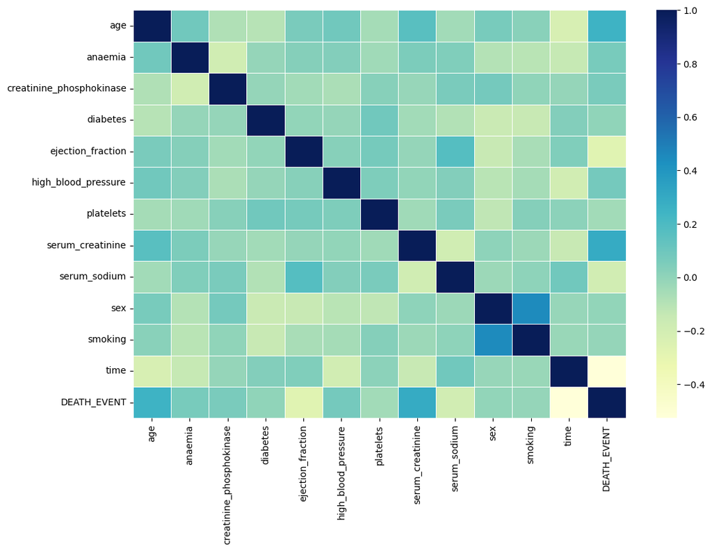

```python
 # Find correlation
corr = df.corr()

# plot the heatmap
plt.figure(figsize = (12,8))
sns.heatmap(corr,
        xticklabels=corr.columns,
        linewidth=0.5,
        yticklabels=corr.columns,
           cmap="YlGnBu")
plt.show()
```

### Store Features into a feature matrix X and Response variable into a response vector y:

```python
#Features
#loc[what rows, what cols]
X = df.loc[:,df.columns != 'DEATH_EVENT']
#Response
y = df['DEATH_EVENT']
```

### Use SMOTE to handle class imbalance in dataset:

```python
from imblearn.over_sampling import SMOTE
s = SMOTE()
X_, y_= s.fit_resample(X,y)
```

### CHeck the class values counts, now we have class values equally distributed:

```python
from collections import Counter
print(Counter(y_))
```

```
Counter({1: 203, 0: 203})
```

## Classification Techniques:

### Divide the dataset into training set and testing set (80 percent train and 20 percent test):

```python
from sklearn.model_selection import train_test_split
X_train, X_test, y_train, y_test = train_test_split(X_ , y_,  test_size=0.20, random_state=42)
```

### Scaled the dataset using StandardScaler:

```python
scaler = StandardScaler()
X_train_scaled = scaler.fit_transform(X_train)
X_test_scaled = scaler.fit_transform(X_test)
```

# Logistic Regression Model:

### Fit the Logistic Regression model on training set and make prediction on testing set:

```python
#Initialize the model
Lg_classifier = LogisticRegression()
# Fit the model on training set
Lg_classifier.fit(X_train_scaled, y_train)
#  make prediction on testing set
y_pred_lg = Lg_classifier.predict(X_test_scaled)
```

### Evaluate the Logistic Regression model using accuracy score:

```python
accu_lg = accuracy_score(y_pred_lg, y_test)

# Print the prediction accuracy
print('Test Accuracy Logistic Regression :', accu_lg)
```

```
Test Accuracy Logistic Regression : 0.8902439024390244
```

### To get the weights of all the variables Logistic Regression:

```
Axes(0.125,0.11;0.775x0.77)
```

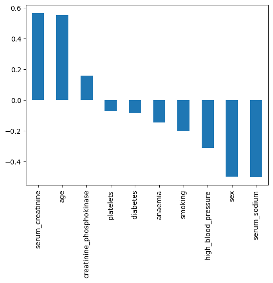

```python
weights = pd.Series(Lg_classifier.coef_[0],
                 index=X.columns.values)
print (weights.sort_values(ascending = False)[:10].plot(kind='bar'))
```

```
Axes(0.125,0.11;0.775x0.77)
```

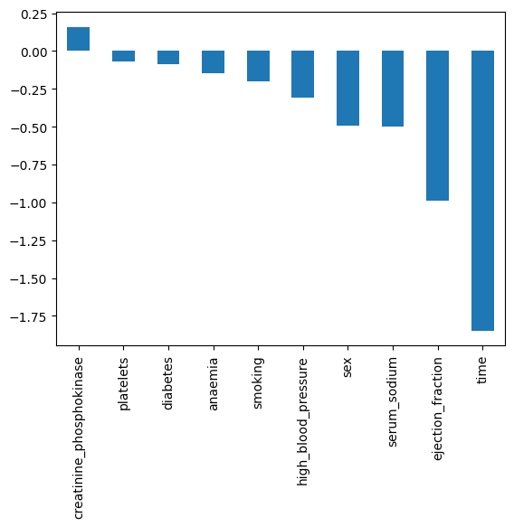

```python
print(weights.sort_values(ascending = False)[-10:].plot(kind='bar'))
```

# Decision Tree Classifier:

### Fit the Decision Tree Classifier on training set and make prediction on testing set:

```python
Dt_classifier = DecisionTreeClassifier(max_depth = 3)

Dt_classifier.fit(X_train_scaled, y_train)

y_pred_dt = Dt_classifier.predict(X_test_scaled)
```

### Evaluate the Decision Tree Classifier using accuracy score:

```python
accu_dt = accuracy_score(y_pred_dt, y_test)

# Print the prediction accuracy
print('Test Accuracy Decision Tree Classifier :', accu_dt)
```

```
Test Accuracy Decision Tree Classifier : 0.7682926829268293
```

# Random Forest Classifier:

### Fit the Random Forest Classifier on training set and make prediction on testing set:

```python
Rf_classifier = RandomForestClassifier(n_estimators = 100)

Rf_classifier.fit(X_train_scaled, y_train)

y_pred_rf = Rf_classifier.predict(X_test_scaled)
```

### Evaluate the Random Forest Classifier using accuracy score:

```python
accu_rf = accuracy_score(y_pred_rf, y_test)

# Print the prediction accuracy
print('Test Accuracy Random Forest Classifier :', accu_rf)
```

```
Test Accuracy Random Forest Classifier : 0.8170731707317073
```

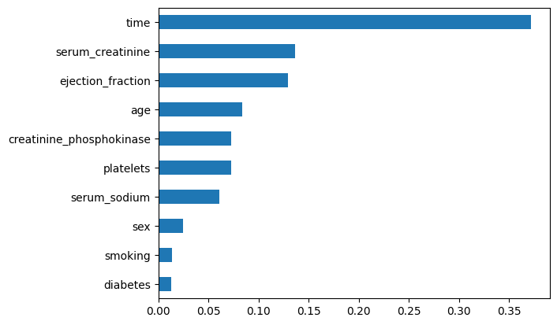

```python
importances = Rf_classifier.feature_importances_
weights = pd.Series(importances,
                 index=X.columns.values)
weights.sort_values()[-10:].plot(kind = 'barh')
```

# Support Vector Machine Classifier:

### Fit the Support Vector Machine Classifier on training set and make prediction on testing set:

```python
Rf_Svc = SVC(C = 0.01)

Rf_Svc.fit(X_train_scaled, y_train)

y_pred_svc = Rf_Svc.predict(X_test_scaled)
```

### Evaluate the Support Vector Machine Classifier using accuracy score:

```python
accu_svc = accuracy_score(y_pred_svc, y_test)

# Print the prediction accuracy
print('Test Accuracy Support Vector Machine Classifier :', accu_svc)
```

```
Test Accuracy Support Vector Machine Classifier : 0.8170731707317073
```

# Ada Boost Classifier:

### Fit the Ada Boost Classifier on training set and make prediction on testing set:

```python
Ab_classifier = AdaBoostClassifier(n_estimators = 100)

Ab_classifier.fit(X_train_scaled, y_train)

y_pred_ab = Ab_classifier.predict(X_test_scaled)
```

### Evaluate the Ada Boost Classifier using accuracy score:

```python
accu_ab = accuracy_score(y_pred_ab, y_test)

# Print the prediction accuracy
print('Test Accuracy AdaBoost Classifier :', accu_ab)
```

```
Test Accuracy AdaBoost Classifier : 0.8536585365853658
```

# K-nearest Neighbour Classifier:

### Fit the K-nearest Neighbour Classifier on training set and make prediction on testing set:

```python
Knn_classifier = KNeighborsClassifier(n_neighbors=100)

Knn_classifier.fit(X_train_scaled, y_train)

y_pred_knn = Knn_classifier.predict(X_test_scaled)
```

### Evaluate the K-nearest Neighbour Classifier using accuracy score:

```python
accu_knn = accuracy_score(y_pred_knn, y_test)

# Print the prediction accuracy
print('Test accuracy K-nearest Neighbour Classifier :', accu_knn)
```

```
Test accuracy K-nearest Neighbour Classifier : 0.8414634146341463
```

### Classification Model Comparison:

### Comparing Classification models(in terms of Accuracy score) in the form of a table:

```python
scores = pd.Series([accu_lg, accu_dt, accu_rf,accu_svc, accu_ab, accu_knn,  ])
models = ['Logistic Regression','DecisionTree Classifier','RandomForest Classifier', 'SVM Classifier' ,'AdaBoost Classifier' ,'KNN Classifier','CNN Model']

# Comparing models' performance
performance = pd.DataFrame(list(zip(models, scores)), columns=['Models', 'R2_score'])

# Displaying the performance table
performance
```

|  | Models | R2_score |
| --- | --- | --- |
| 0 | Logistic Regression | 0.890244 |
| 1 | DecisionTree Classifier | 0.768293 |
| 2 | RandomForest Classifier | 0.817073 |
| 3 | SVM Classifier | 0.817073 |
| 4 | AdaBoost Classifier | 0.853659 |
| 5 | KNN Classifier | 0.841463 |

### Comparing Classification models in the form of a bar graph

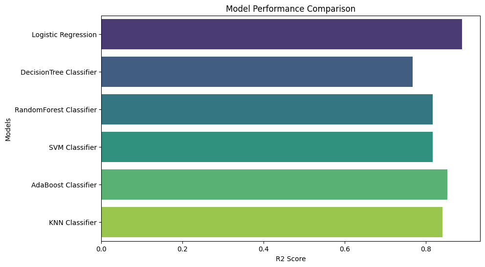

```python
plt.figure(figsize=(10, 6))
sns.barplot(x='R2_score', y='Models', data=performance, palette='viridis')
plt.xlabel('R2 Score')
plt.ylabel('Models')
plt.title('Model Performance Comparison')
plt.show()
```